# task 2

#Polecenie Weźmy pod uwagę wszystkie kierunki, które mają słowo “informatyka” w nazwie. W zbiorze są zarówno informacje o absolwentach studiów I stopnia, jak również II stopnia. Skupiając się tylko na tych kierunkach, na których co najmniej 25 osób zdobyło licencjat oraz 25 osób obroniło tytuł zawodowy magistra, zaprezentuj jak kształtują się zarobki absolwentów I i II stopnia pięć lat od uzyskania dyplomu. Zaproponuj wskaźnik opisujący “zwrot z inwestycji”, polegającej na zdobyciu tytułu zawodowego magistra dla każdego z tych kierunków. Zaprezentuj dane w dowolny sposób. Dołącz skrypt R lub Python

zaprezentuj jak kształtują się zarobki absolwentów I i II stopnia pięć lat od uzyskania dyplomu. Zaproponuj wskaźnik opisujący “zwrot z inwestycji”, polegającej na zdobyciu tytułu zawodowego magistra dla każdego z tych kierunków. Zaprezentuj dane w dowolny sposób. Dołącz skrypt R lub Python

```r
library(tidyverse)
library(tibble)
library(purrr)
library(reshape2)
library(ggplot2)
library(ggthemes)
library(ggpubr)

graduates_major_data_1_ <- read_delim("graduates-major-data (1).csv",
    delim = ";", escape_double = FALSE, col_types = cols(P_ROKDYP = col_integer(),
        P_KIERUNEK_ID = col_integer(), P_N = col_integer(),
        P_N_WZUS = col_integer(), P_N_POZAZUS = col_integer(),
        P_PROC_WZUS = col_integer(), P_PROC_POZAZUS = col_integer()),
    trim_ws = TRUE)
tib0 <-as_tibble(graduates_major_data_1_)
```

#Plan filter 0) ma słowo informatyka w nazwie 1)co najmniej 25 osób zdobyło licencjat %and% 25 osób obroniło tytuł zawodowy magistra– w zalezności od tabeli 2)join w celu polaczenia danych dla absolwentow studiów I stopnia, jak również II stopnia 3)kierunki ze słowem “informatyka” w nazwie 4)wykres zarobki absolwentów I i II stopnia pięć lat od uzyskania dyplomu 5) Zaproponuj wskaźnik opisujący “zwrot z inwestycji”, polegającej na zdobyciu tytułu zawodowego magistra dla każdego z tych kierunków a) na przykład o ile wiecej sa w stanie zarobić niż ci z I stopniem jedynie - jak szybko sa w stanie nadobić te pieniadze co inzynierowie zarobili podczas gdy Ci studiowali uwzglednic mozna czy pracowali podczas studiów II stopnia

```r
primTibble<-as_tibble(graduates_major_data_1_)%>%
select(P_KIERUNEK_NAZWA,P_POZIOM,P_N,P_E_ZAR_P5,P_ME_ZAR_P5,P_N_DOSW_REKR,P_N_DOSW_STUDIA,P_N_NDOSW  ) %>%
drop_na(P_E_ZAR_P5,P_ME_ZAR_P5,P_N )%>% #jesli nie mamy danych ignorujemy
# frazy jak " - k. unikatowy" i "Makrokierunek -"  nie dodaja nowych wiadomosci
mutate(P_KIERUNEK_NAZWA = map_chr(P_KIERUNEK_NAZWA, ~str_replace(.x,
                                         pattern = " - k. unikatowy",
                                         replacement = "")))%>%
mutate(P_KIERUNEK_NAZWA = map_chr(P_KIERUNEK_NAZWA, ~str_replace(.x,
                                         pattern = "Makrokierunek -",
                                         replacement = "")))%>%
mutate(P_KIERUNEK_NAZWA = map_chr(P_KIERUNEK_NAZWA, ~tolower(.x)))%>% # tak aby wyszukiwanie nie bylo zalezne od wielkosci liter
filter(str_detect(P_KIERUNEK_NAZWA, "informatyka"))%>% # kierunki z słowem informatyka w nazwie
group_by(P_KIERUNEK_NAZWA,P_POZIOM)%>%# oddzielnie traktujemy studia inzynierskie i magisterskie
summarise(mediana_kierunek = median(P_ME_ZAR_P5, na.rm = TRUE)
          ,srednia_Kierunek = mean(P_E_ZAR_P5, na.rm = TRUE)
          ,P_NSum = sum(P_N, na.rm = TRUE)
          ,N_DOSW_REKR=  sum(P_N_DOSW_REKR, na.rm = TRUE)
          ,N_DOSW_STUDIA=  sum(P_N_DOSW_STUDIA, na.rm = TRUE)
          ,N_NDOSW=  sum(P_N_NDOSW, na.rm = TRUE)
          )%>% # agregacja danych o kierunku pomiedzy uczelniami
filter(P_NSum>25)%>%#interesuja nas tylko odpowiednio liczne kierunki
group_by(P_KIERUNEK_NAZWA)%>%# teraz chcemy jedynie kierunkow które spełniły kryterium liczności zarowno dla studiow magisterskich jak i licencjackich
filter(n()==2)
primTibble
```

| P_KIERUNEK_NAZWA | P_POZIOM | mediana_kierunek | srednia_Kierunek | P_NSum | N_DOSW_REKR | N_DOSW_STUDIA | N_NDOSW |
| --- | --- | --- | --- | --- | --- | --- | --- |
| automatyka i robot.,elektronika i telekom., informatyka | 1 | 758522.0 | 757500.0 | 86 | 1 | 1 | 84 |
| automatyka i robot.,elektronika i telekom., informatyka | 2 | 896558.5 | 894978.5 | 49 | 3 | 7 | 39 |
| elektronika, informatyka i telekomunikacja | 1 | 926117.5 | 928861.5 | 408 | 27 | 31 | 350 |
| elektronika, informatyka i telekomunikacja | 2 | 1175604.5 | 116701.0 | 110 | 29 | 26 | 55 |
| informatyka przemyslowa | 1 | 395961.0 | 754103.5 | 63 | 0 | 6 | 57 |
| informatyka przemyslowa | 2 | 846579.0 | 935247.0 | 72 | 27 | 29 | 16 |
| bioinformatyka i biologia systemów | 1 | 831818.0 | 756666.5 | 36 | 0 | 0 | 36 |
| bioinformatyka i biologia systemów | 2 | 445015.5 | 69784.5 | 42 | 3 | 3 | 36 |
| informatyka | 1 | 552946.0 | 634800.6 | 13481 | 353 | 3235 | 9893 |
| informatyka | 2 | 783224.0 | 856685.4 | 5831 | 621 | 1862 | 3348 |

[output cut: 8 more lines]

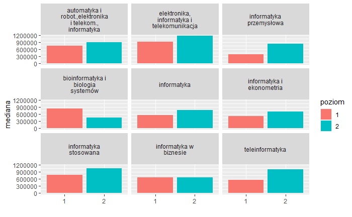

```r
ggplot(data = primTibble)+
    facet_wrap(~P_KIERUNEK_NAZWA, labeller = label_wrap_gen(17)) +
  geom_bar(aes(P_POZIOM, mediana_kierunek, fill = P_POZIOM), stat = "identity")+
  scale_x_discrete(labels = function(x) str_wrap(x, width = 10))+
  xlab("")+
  ylab("mediana")+
  guides(fill=guide_legend(title="poziom"))
```

```r
# ggplot(data = primTibble)+
#     facet_wrap(~P_KIERUNEK_NAZWA) +
#   geom_bar(aes(P_POZIOM, 'mediana kierunek', fill = P_POZIOM), stat = "identity")+
#   scale_x_discrete(labels = function(x) str_wrap(x, width = 10))
```

```r
namesOfIntrest<- primTibble %>%
  select(P_KIERUNEK_NAZWA)%>%
  distinct


tibOnlyFacultyOfIntr<- tib0%>%
select(P_KIERUNEK_NAZWA,P_POZIOM,P_N,       P_E_ZAR_NDOSW_P1, P_E_ZAR_NDOSW_P2,  P_E_ZAR_NDOSW_P3, P_E_ZAR_NDOSW_P4, P_E_ZAR_NDOSW_P5,P_E_ZAR_PODCZAS_STUDIOW_DOSW_REKR,P_E_ZAR_PODCZAS_STUDIOW_DOSW_STUDIA) %>%
  # frazy jak " - k. unikatowy" i "Makrokierunek -"  nie dodaja nowych wiadomosci
mutate(P_KIERUNEK_NAZWA = map_chr(P_KIERUNEK_NAZWA, ~str_replace(.x,
                                         pattern = " - k. unikatowy",
                                         replacement = "")))%>%
mutate(P_KIERUNEK_NAZWA = map_chr(P_KIERUNEK_NAZWA, ~str_replace(.x,
                                         pattern = "Makrokierunek -",
                                         replacement = "")))%>%
mutate(P_KIERUNEK_NAZWA = map_chr(P_KIERUNEK_NAZWA, ~tolower(.x)))%>%
filter(P_KIERUNEK_NAZWA %in% namesOfIntrest$P_KIERUNEK_NAZWA)
tibOnlyFacultyOfIntr
```

| P_KIERUNEK_NAZWA | P_POZIOM | P_N | P_E_ZAR_NDOSW_P1 | P_E_ZAR_NDOSW_P2 | P_E_ZAR_NDOSW_P3 | P_E_ZAR_NDOSW_P4 | P_E_ZAR_NDOSW_P5 | P_E_ZAR_PODCZAS_STUDIOW_DOSW_REKR | P_E_ZAR_PODCZAS_STUDIOW_DOSW_STUDIA |
| --- | --- | --- | --- | --- | --- | --- | --- | --- | --- |
| informatyka | 2 | 12 | NA | NA | NA | NA | NA | NA | NA |
| informatyka | 2 | 28 | 35788 | 377963 | 548065 | 545872 | 613055 | NA | 330121 |
| informatyka | 2 | 23 | 419335 | 513503 | 596077 | 75932 | 871141 | NA | 525827 |
| informatyka | 2 | 54 | 432384 | 552675 | 665444 | 660707 | 808561 | NA | 455988 |
| informatyka | 1 | 17 | 227256 | 224474 | 283576 | NA | NA | NA | 193486 |
| informatyka | 1 | 30 | 160439 | 201551 | 266492 | 303135 | 345718 | NA | NA |
| informatyka | 1 | 21 | NA | NA | NA | NA | NA | NA | NA |
| informatyka | 1 | 14 | 385225 | 452266 | 426376 | 60218 | 686376 | NA | 331567 |
| informatyka | 1 | 36 | 142371 | 259387 | 309632 | 356329 | 382957 | NA | 182435 |
| informatyka | 1 | 13 | 167251 | 185379 | 248462 | 308962 | 361361 | NA | 241448 |

[output cut: 990 more lines]

P_E_ZAR_PODCZAS_STUDIOW_DOSW_REKR Średnie miesięczne wynagrodzenie ze wszystkich źródeł w trakcie studiów absolwentów wśród absolwentów z doświadczeniem pracy przed uzyskaniem dyplomu P_E_ZAR_PODCZAS_STUDIOW_DOSW_STUDIA Średnie miesięczne wynagrodzenie ze wszystkich źródeł w trakcie studiów absolwentów nie mających doświadczenia pracy przed rozpoczęciem studiów, ale uzyskali je w trakcie studiów

```r
#zwraca model liniowy dla danego kierunku i dla danego poziomu studiów - magisterskie lub licencjackie
getTibForLinModel<-function(nazwaKierunku,stopienNum,tibOnlyFacultyOfIntr ){

  resTib<-tibOnlyFacultyOfIntr%>%
  filter(P_KIERUNEK_NAZWA==nazwaKierunku)%>%
  filter(P_POZIOM==stopienNum)%>%
  select(P_E_ZAR_NDOSW_P1,P_E_ZAR_NDOSW_P2, P_E_ZAR_NDOSW_P3,P_E_ZAR_NDOSW_P4, P_E_ZAR_NDOSW_P5)  %>%
  rownames_to_column%>%
  pivot_longer(, cols=-rowname)%>%
  mutate(name = map_chr(name, ~str_replace(.x,
                                            pattern = "P_E_ZAR_NDOSW_P1",
                                            replacement = '1')))%>%
  mutate(name = map_chr(name, ~str_replace(.x,
                                            pattern = "P_E_ZAR_NDOSW_P2",
                                            replacement = '2')))%>%
  mutate(name = map_chr(name, ~str_replace(.x,
                                            pattern = "P_E_ZAR_NDOSW_P3",
                                            replacement = '3')))%>%
  mutate(name = map_chr(name, ~str_replace(.x,
                                          pattern = "P_E_ZAR_NDOSW_P4",
                                            replacement = '4')))%>%
  mutate(name = map_chr(name, ~str_replace(.x,     pattern = "P_E_ZAR_NDOSW_P5",
                                            replacement = '5')))%>%
  mutate(across(name, as.integer))%>%
  select(name,value)%>%
  drop_na(value)

  #model<-lm(value~name , resTib)

  return(resTib)
}
```

Plan do oszacowania czasu zwrotu uczęścania na studia magisterskie Zalozenia - zakładamy że studenci studiow magisterskich stanowią głównie studenci którzy skończyli studia inżynierskie na tym samym kierunku - zakłądamy że doświadczenie jest ważną zmienną wpływającą na wysokość zarobków - jako że celem jest jak najbardziej izolowana ocena wartości dodanej dzięki studiom porównujemy jedynie studentów bez doświadczenia - wtedy mozemy też zignorować wysokość zarobków w trakcie studiów jako że jeśli nawet one są większe od zera z dużym prawdopodobieństwem nie świadczą o pracy w zawodzie - skoro nie włączają się do doświadczenia - problemem jest różnica zarobków związana z miejscem zamieszkania - problem ten mógłby być potencjalnie rozwiązany przez uwzględnienie zarobków względem wartości dla powiatu - jednak w tym wypadku trudne było0by oszacowanie czasu zwrotu zwiazanego z pojsciem na studia magisterskie

Hipoteza - zarobki po skonczeniu studiow magisterskich sa wyższe niż bez.

```r
getSinglePlotOfIncome<-function(nazwaKierunku,tibOnlyFacultyOfIntr ){


  tibbInzynier<-getTibForLinModel(nazwaKierunku,1,tibOnlyFacultyOfIntr )%>%
    group_by(name)%>%
    summarise(zarobki = mean(value, na.rm = TRUE)      )%>%
    rename(zarobkiInz=zarobki )


  tibbMagister<-getTibForLinModel(nazwaKierunku,2,tibOnlyFacultyOfIntr )%>%
    group_by(name)%>%
    summarise(zarobki = mean(value, na.rm = TRUE)      )    %>%
    rename(zarobkiMag=zarobki )

  joinedTabl<-inner_join(tibbInzynier, tibbMagister, by='name')%>%
  add_column(diff=.$zarobkiMag- .$zarobkiInz)
  d <- melt(joinedTabl, id.vars="name")
  plot<-ggplot(d, aes(name,value, col=variable)) +
    geom_point() +
    stat_smooth() +
    xlab("rok po obronie dyplomu")+
  ylab("średnie zarobki")+
  guides(fill=guide_legend(title="legenda"))+
  ggtitle(nazwaKierunku)
  return(plot)
}
```